# HW 5: Unabomber Hypothesis

Melanie Kos

# Instructions

Modify unambomber so you apply pro template Improve your cleaning genie so you’re happy rename the genie first name_genie Summarize your corpus with new cleaning data Write out your hypothesis about unabomber Run your four variables Visualize results Describe the results in human words

# Summarize corpus with new clean data

Let’s load in the Unabomber data and run `melanie_genie` on it.

```r
unabomb <- paste(readLines('https://raw.githubusercontent.com/Reilly-ConceptsCognitionLab/reillylab_publicdata/main/unabomber_manifesto.txt'))
unabomb_clean <- melanie_genie(unabomb, return_base_text = TRUE)
```

```
## For information on available language packages for 'koRpus', run
##
##   available.koRpus.lang()
##
## and see ?install.koRpus.lang()
```

```r
unabomb_base <- unabomb_clean$base_text
unabomb_tokendf <- unabomb_clean$token_df
unabomb_typedf  <- unabomb_clean$type_df

unabomb_base[1:50]
```

```
##  [1] "industrial society and its future"
##  [2] ""
##  [3] "introduction"
##  [4] ""
##  [5] "the industrial revolution and its consequence have be a disaster for the"
##  [6] "human race they have greatly increase the life expectancy of that of us"
##  [7] "who live in advance country but they have destabilize society have"
##  [8] "make life unfulfilling have subject human being to indignity have lead"
##  [9] "to widespread psychological suffer in the 3 world to physical"
## [10] "suffer as good and have inflict severe damage on the natural world the"
## [11] "continue development of technology will worsen the situation it will"
## [12] "certainly subject human being to great indignity and inflict great"
## [13] "damage on the natural world it will probably lead to great social"
## [14] "disruption and psychological suffer and it may lead to increase physical"
## [15] "suffer even in advance country"
```

[output cut: 35 more lines]

```r
unabomb_tokendf
```

```
## # A tibble: 34,353 × 6
##    id_row_orig word_raw     word_lemma   word_clean   n_raw n_clean
##          <int> <chr>        <chr>        <chr>        <int>   <int>
##  1           1 industrial   industrial   industrial      88      88
##  2           1 society      society      society        271     271
##  3           1 and          and          <NA>           742      NA
##  4           1 its          its          <NA>            54      NA
##  5           1 future       future       future          10      10
##  6           3 introduction introduction introduction     8       8
##  7           5 the          the          <NA>          1892      NA
##  8           5 industrial   industrial   industrial      88      88
##  9           5 revolution   revolution   revolution      55      55
## 10           5 and          and          <NA>           742      NA
## # ℹ 34,343 more rows
```

```r
unabomb_typedf
```

```
## # A tibble: 32,323 × 6
##    id_row_orig word_raw     word_lemma   word_clean   n_raw n_clean
##          <int> <chr>        <chr>        <chr>        <int>   <int>
##  1           1 and          and          <NA>             1      NA
##  2           1 future       future       future           1       1
##  3           1 industrial   industrial   industrial       1       1
##  4           1 its          its          <NA>             1      NA
##  5           1 society      society      society          1       1
##  6           3 introduction introduction introduction     1       1
##  7           5 a            a            <NA>             1      NA
##  8           5 and          and          <NA>             1      NA
##  9           5 be           be           <NA>             1      NA
## 10           5 consequence  consequence  consequence      1       1
## # ℹ 32,313 more rows
```

Yay, cleaned Unabomber data! Now, let’s load the metadata set and create a new dataframe with it to characterize the Unabomber text. I’ll use the token dataframe output (which preserves naturally preserves the word frequency in the `word_clean` column; otherwise, would have to weight each row of `type_df` based on `n_clean` value).

```r
# Load BIG lookup database
load(url("https://github.com/Reilly-ConceptsCognitionLab/reillylab_publicdata/blob/main/lookup_Jul25.rda?raw=true"))
lookup_db <- lookup_Jul25

unabomb_meta <- unabomb_tokendf |>
  left_join(lookup_db,
            by = c("word_clean" = "word"))
unabomb_meta
```

```
## # A tibble: 34,353 × 51
##    id_row_orig word_raw     word_lemma   word_clean   n_raw n_clean emo_anger
##          <int> <chr>        <chr>        <chr>        <int>   <int>     <dbl>
##  1           1 industrial   industrial   industrial      88      88    0.0089
##  2           1 society      society      society        271     271    0.0001
##  3           1 and          and          <NA>           742      NA   NA
##  4           1 its          its          <NA>            54      NA   NA
##  5           1 future       future       future          10      10   -0.193
##  6           3 introduction introduction introduction     8       8   -0.190
##  7           5 the          the          <NA>          1892      NA   NA
##  8           5 industrial   industrial   industrial      88      88    0.0089
##  9           5 revolution   revolution   revolution      55      55    0.131
## 10           5 and          and          <NA>           742      NA   NA
## # ℹ 34,343 more rows
## # ℹ 44 more variables: emo_anger_rescale <dbl>, emo_anxiety <dbl>,
## #   emo_anxiety_rescale <dbl>, emo_arousal_b24 <dbl>,
## #   emo_arousal_b24_rescale <dbl>, emo_boredom <dbl>,
## #   emo_boredom_rescale <dbl>, emo_confusion <dbl>,
## #   emo_confusion_rescale <dbl>, emo_excitement <dbl>,
## #   emo_excitement_rescale <dbl>, emo_guilt <dbl>, emo_guilt_rescale <dbl>, …
```

```r
colnames(unabomb_meta)
```

```
##  [1] "id_row_orig"             "word_raw"
##  [3] "word_lemma"              "word_clean"
##  [5] "n_raw"                   "n_clean"
##  [7] "emo_anger"               "emo_anger_rescale"
##  [9] "emo_anxiety"             "emo_anxiety_rescale"
## [11] "emo_arousal_b24"         "emo_arousal_b24_rescale"
## [13] "emo_boredom"             "emo_boredom_rescale"
## [15] "emo_confusion"           "emo_confusion_rescale"
## [17] "emo_excitement"          "emo_excitement_rescale"
## [19] "emo_guilt"               "emo_guilt_rescale"
## [21] "emo_happiness"           "emo_happiness_rescale"
## [23] "emo_intensity"           "emo_intensity_recale"
## [25] "emo_sadness"             "emo_sadness_rescale"
## [27] "emo_trust"               "emo_trust_rescale"
## [29] "emo_valence_b24"         "emo_valence_b24_rescale"
## [31] "lex_AoA"                 "lex_AoA_rescale"
## [33] "lex_freqlg10"            "lex_freqlg10_rescale"
## [35] "lex_n_morphemes"         "lex_n_senses"
## [37] "lex_n_senses_rescale"    "phon_n_lett"
## [39] "phon_nsyll"              "sem_auditory"
## [41] "sem_auditory_rescale"    "sem_cnc_b24"
## [43] "sem_cnc_b24_rescale"     "sem_cnc_v2013"
## [45] "sem_cnc_v2013_rescale"   "sem_diversity"
## [47] "sem_diversity_rescale"   "sem_neighbors"
## [49] "sem_neighbors_rescale"   "sem_visual"
## [51] "sem_visual_rescale"
```

# Hypothesis about Unabomber

Nice, now we can see `unabomb_meta` with sentiment information about the words in the manifesto.

I’m wondering about the underlying emotions that motivated his actions. I’m going to look at anger, anxiety, sadness, and trust. I would expect his motivations to be high anger, high anxiety, medium sadness, and low trust. However, given that we’re looking an ideological and more technical document, I would expect results to reflect low “concrete”, primary emotions (like anger, sadness) and high “abstract”, secondary emotions (like anxiety, trust) as he talks about <sub>society</sub> and this analysis focuses on the lexical content rather than an internal psychological state.

```r
my_lookup <- unabomb_meta |> select(4, 8, 10, 26, 28) # word_clean, anger (rescaled), anxiety (rescaled), sadness (rescaled), trust (rescaled)
str(my_lookup)
```

```
## tibble [34,353 × 5] (S3: tbl_df/tbl/data.frame)
##  $ word_clean         : chr [1:34353] "industrial" "society" NA NA ...
##  $ emo_anger_rescale  : num [1:34353] 2.52 2.46 NA NA 1.19 ...
##  $ emo_anxiety_rescale: num [1:34353] 2.74 2.72 NA NA 1.75 ...
##  $ emo_sadness_rescale: num [1:34353] 2.36 2.83 NA NA 1.27 ...
##  $ emo_trust_rescale  : num [1:34353] 1.85 2.92 NA NA 3.7 ...
```

# Run four variables

Let’s get the means and standard deviations for the 4 emotions:

```r
emotion_summary <- my_lookup |>
  summarise(across(where(is.numeric), list(mean = ~mean(.x, na.rm = TRUE), sd = ~sd(.x, na.rm = TRUE))))
emotion_summary
```

```
## # A tibble: 1 × 8
##   emo_anger_rescale_mean emo_anger_rescale_sd emo_anxiety_rescale_mean
##                    <dbl>                <dbl>                    <dbl>
## 1                   2.26                0.728                     2.35
## # ℹ 5 more variables: emo_anxiety_rescale_sd <dbl>,
## #   emo_sadness_rescale_mean <dbl>, emo_sadness_rescale_sd <dbl>,
## #   emo_trust_rescale_mean <dbl>, emo_trust_rescale_sd <dbl>
```

# Visualize and interpret results

Let’s visualize these means and SDs:

```r
library(tidyr)
library(dplyr)
library(ggplot2)

emotion_plotSummary <- emotion_summary |>
  # Pivot longer and split on column names to create emotion and mean and sd columns
  pivot_longer(cols = everything(), names_to = c("emotion", ".value"), names_pattern = "(.*)_(mean|sd)") |>
  mutate(emotion = stringr::str_extract(emotion, "anger|anxiety|sadness|trust")) # Let's go string extract lol
emotion_plotSummary
```

```
## # A tibble: 4 × 3
##   emotion  mean    sd
##   <chr>   <dbl> <dbl>
## 1 anger    2.26 0.728
## 2 anxiety  2.35 0.728
## 3 sadness  2.19 0.792
## 4 trust    2.94 0.744
```

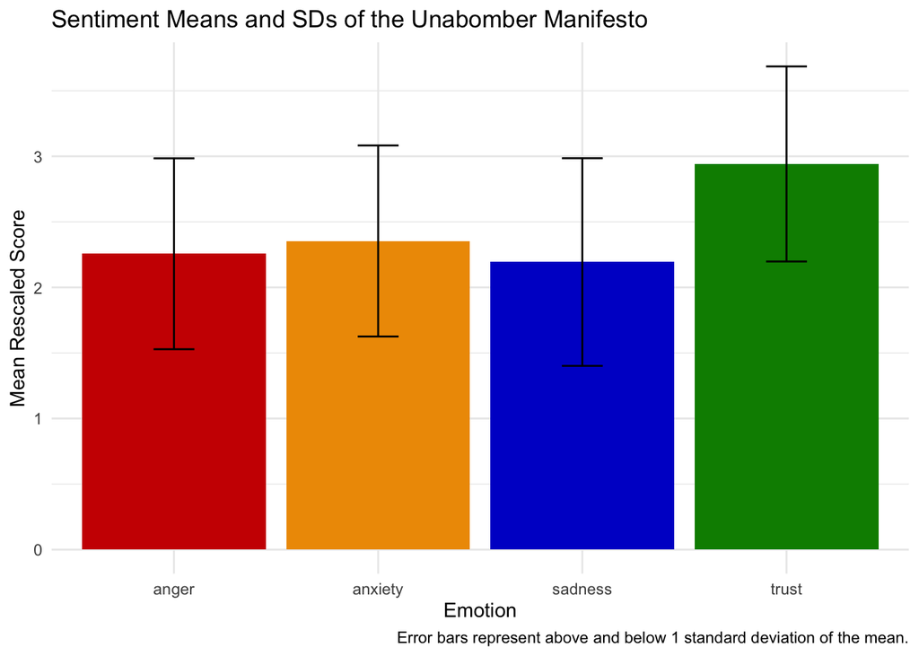

```r
ggplot(emotion_plotSummary, aes(x = emotion, y = mean, fill = emotion)) +
  geom_col() +
  geom_errorbar(aes(ymin = mean - sd,
                    ymax = mean + sd),
                width = 0.2) +
  scale_fill_manual(values = c(
    anger   = "red3",
    anxiety = "orange2",
    sadness = "blue3",
    trust   = "green4")) +
  labs(title = "Sentiment Means and SDs of the Unabomber Manifesto",
       x = "Emotion",
       y = "Mean Rescaled Score",
       caption = "Error bars represent above and below 1 standard deviation of the mean.") +
  theme_minimal() +
  theme(legend.position = "none")
```

We see that the Unabomber Manifesto is highest in words associated with “trust”, with a mean value of 2.9, followed by “anxiety” at 2.4, and then “anger” and “sadness” with mean values of 2.3 and 2.2, respectively. These values still reflect the normative emotional ratings of the *words* used in the text, and thus don’t necessarily reflect the actual emotional state of of Ted Kaczynski. So while these “abstract”, secondary emotions are more commonly encoded than “concrete”, primary emotions based on the lexical content, this just means that words associated with these emotions are more often used in the text, and there’s not necessarily a statistically significant difference between the emotion categories.